# GBIF

# How to get “country code”?

Country codes are stored in “isocodes”, a data.frame that comes with rgbif package.

```r
head(isocodes)
```

```
##   code                 name            gbif_name
## 1   AD              Andorra              ANDORRA
## 2   AE United Arab Emirates UNITED_ARAB_EMIRATES
## 3   AF          Afghanistan          AFGHANISTAN
## 4   AG  Antigua and Barbuda      ANTIGUA_BARBUDA
## 5   AI             Anguilla             ANGUILLA
## 6   AL              Albania              ALBANIA
```

e.g Country code for United States in the GBIF system.

```r
isocodes[grep("^United States$", isocodes$name), "code"]
```

```
## [1] "US"
```

# Search for occurence records

`occ_search()` will return up to 500 occurence records that are defined in its’ argumentation.

occ_search() arguments: taxonKey = NULL, scientificName = NULL, country = NULL, publishingCountry = NULL, hasCoordinate = NULL, typeStatus = NULL, recordNumber = NULL, lastInterpreted = NULL, continent = NULL, geometry = NULL, geom_big = “asis”, geom_size = 40, geom_n = 10, recordedBy = NULL, basisOfRecord = NULL, datasetKey = NULL, eventDate = NULL, catalogNumber = NULL, year = NULL, month = NULL, decimalLatitude = NULL, decimalLongitude = NULL, elevation = NULL, depth = NULL, institutionCode = NULL, collectionCode = NULL, hasGeospatialIssue = NULL, issue = NULL, search = NULL, mediaType = NULL, subgenusKey = NULL, repatriated = NULL, phylumKey = NULL, kingdomKey = NULL, classKey = NULL, orderKey = NULL, familyKey = NULL, genusKey = NULL, establishmentMeans = NULL, protocol = NULL, license = NULL, organismId = NULL, publishingOrg = NULL, stateProvince = NULL, waterBody = NULL, locality = NULL, limit = 500, start = 0, fields = “all”, return = “all”, spellCheck = NULL, facet = NULL, facetMincount = NULL, facetMultiselect = NULL, skip_validate = TRUE, curlopts = list(),…

e.g. Taxon: *Ambrosia intergradiens* Country: Unites States

```r
# Country Code
usa_code <- isocodes[grep("^United States$", isocodes$name), "code"]

occurrence_data <- occ_search(scientificName = "Ambrosia intergradiens", country=usa_code, hasCoordinate = TRUE, return='data')
head(occurrence_data)
```

```
## # A tibble: 6 x 82
##   key   scientificName decimalLatitude decimalLongitude issues datasetKey
##   <chr> <chr>                    <dbl>            <dbl> <chr>  <chr>
## 1 2236~ Ambrosia inte~            46.6            -87.4 cdrou~ 50c9509d-~
## 2 1988~ Ambrosia inte~            46.5            -87.4 gass84 c8d12f8a-~
## 3 1988~ Ambrosia inte~            44.1            -85.1 ""     c8d12f8a-~
## 4 1989~ Ambrosia inte~            43.6            -85.5 gass84 c8d12f8a-~
## 5 1989~ Ambrosia inte~            43.6            -85.5 gass84 c8d12f8a-~
## 6 1988~ Ambrosia inte~            45.2            -85.0 gass84 c8d12f8a-~
## # ... with 76 more variables: publishingOrgKey <chr>, networkKeys <chr>,
## #   installationKey <chr>, publishingCountry <chr>, protocol <chr>,
## #   lastCrawled <chr>, lastParsed <chr>, crawlId <int>, extensions <chr>,
## #   basisOfRecord <chr>, taxonKey <int>, kingdomKey <int>,
## #   phylumKey <int>, classKey <int>, orderKey <int>, familyKey <int>,
## #   genusKey <int>, speciesKey <int>, acceptedTaxonKey <int>,
## #   acceptedScientificName <chr>, kingdom <chr>, phylum <chr>,
## #   order <chr>, family <chr>, genus <chr>, species <chr>,
## #   genericName <chr>, specificEpithet <chr>, taxonRank <chr>,
## #   taxonomicStatus <chr>, dateIdentified <chr>,
## #   coordinateUncertaintyInMeters <dbl>, stateProvince <chr>, year <int>,
## #   month <int>, day <int>, eventDate <chr>, modified <chr>,
## #   lastInterpreted <chr>, references <chr>, license <chr>,
## #   identifiers <chr>, facts <chr>, relations <chr>, geodeticDatum <chr>,
## #   class <chr>, countryCode <chr>, country <chr>, rightsHolder <chr>,
## #   identifier <chr>, http...unknown.org.nick <chr>,
## #   informationWithheld <chr>, verbatimEventDate <chr>, datasetName <chr>,
## #   collectionCode <chr>, verbatimLocality <chr>, gbifID <chr>,
## #   occurrenceID <chr>, taxonID <chr>, recordedBy <chr>,
## #   catalogNumber <chr>, http...unknown.org.occurrenceDetails <chr>,
## #   institutionCode <chr>, rights <chr>, eventTime <chr>,
## #   identificationID <chr>, name <chr>, continent <chr>, habitat <chr>,
## #   georeferenceProtocol <chr>, locality <chr>, county <chr>,
## #   fieldNumber <chr>, type <chr>, preparations <chr>, typeStatus <chr>
```

# Obtain occurence records >500

In order to download a large occurence records at once, you need a GBIF account. Store your user name, passward, and email address as your environmental variables (.Rprofile, .Renviron) or simply set them as R objects.

```r
user <- "namiko"
pwd <- "735seibutsu"
email <- "nm0076@mix.wvu.edu"
```

1. Make a download request First, you need to make a download request to the GBIF by using `occ_download()` and let the database compile the data for you. For downloading format, you can choose one from DWCA(Darwin Core Archive), SIMPLE_CSV, and SPECIES_LIST.

e.g. Taxon: genus *Ambrosia* (key = 3110576) Country: United States (code = US) Download format: Darwin Core Archive

```r
dl_Ambrosia_USA <- occ_download('taxonKey = 3110576', 'country = US', format = "DWCA", user = user, pwd = pwd, email = email)
dl_Ambrosia_USA
```

```
## <<gbif download>>
##   Username: namiko
##   E-mail: nm0076@mix.wvu.edu
##   Format: DWCA
##   Download key: 0010354-191105090559680
```

Now, you have to wait for a while, from a few minutes up to 3 hours, depending on the amount of data you requested. Check the status in https://www.gbif.org/user/download

e.g. Import data into environment

```r
# Download key
dl_Ambrosia_USA <- "0009448-191105090559680"

# occ_download_import(): import data into your workspace
Ambrosia_USA <- occ_download_import(key = dl_Ambrosia_USA)
head(Ambrosia_USA)
```

```
## # A tibble: 6 x 237
##   gbifID abstract accessRights accrualMethod accrualPeriodic~ accrualPolicy
##   <int6> <lgl>    <chr>        <lgl>         <lgl>            <lgl>
## 1 24517~ NA       ""           NA            NA               NA
## 2 24517~ NA       ""           NA            NA               NA
## 3 24517~ NA       ""           NA            NA               NA
## 4 24517~ NA       ""           NA            NA               NA
## 5 24517~ NA       ""           NA            NA               NA
## 6 24517~ NA       ""           NA            NA               NA
## # ... with 231 more variables: alternative <lgl>, audience <lgl>,
## #   available <lgl>, bibliographicCitation <chr>, conformsTo <lgl>,
## #   contributor <lgl>, coverage <lgl>, created <chr>, creator <lgl>,
## #   date <lgl>, dateAccepted <lgl>, dateCopyrighted <lgl>,
## #   dateSubmitted <lgl>, description <lgl>, educationLevel <lgl>,
## #   extent <lgl>, format <lgl>, hasFormat <lgl>, hasPart <lgl>,
## #   hasVersion <lgl>, identifier <chr>, instructionalMethod <lgl>,
## #   isFormatOf <lgl>, isPartOf <lgl>, isReferencedBy <lgl>,
## #   isReplacedBy <lgl>, isRequiredBy <lgl>, isVersionOf <lgl>,
## #   issued <lgl>, language <chr>, license <chr>, mediator <lgl>,
## #   medium <lgl>, modified <chr>, provenance <lgl>, publisher <lgl>,
## #   references <chr>, relation <lgl>, replaces <lgl>, requires <lgl>,
## #   rights <chr>, rightsHolder <chr>, source <lgl>, spatial <lgl>,
## #   subject <lgl>, tableOfContents <lgl>, temporal <lgl>, title <lgl>,
## #   type <chr>, valid <lgl>, institutionID <chr>, collectionID <chr>,
## #   datasetID <chr>, institutionCode <chr>, collectionCode <chr>,
## #   datasetName <chr>, ownerInstitutionCode <chr>, basisOfRecord <chr>,
## #   informationWithheld <chr>, dataGeneralizations <chr>,
## #   dynamicProperties <chr>, occurrenceID <chr>, catalogNumber <chr>,
## #   recordNumber <chr>, recordedBy <chr>, individualCount <int>,
## #   organismQuantity <int>, organismQuantityType <chr>, sex <chr>,
## #   lifeStage <chr>, reproductiveCondition <chr>, behavior <lgl>,
## #   establishmentMeans <chr>, occurrenceStatus <chr>, preparations <chr>,
## #   disposition <chr>, associatedReferences <chr>,
## #   associatedSequences <chr>, associatedTaxa <chr>,
## #   otherCatalogNumbers <chr>, occurrenceRemarks <chr>, organismID <chr>,
## #   organismName <lgl>, organismScope <lgl>, associatedOccurrences <lgl>,
## #   associatedOrganisms <lgl>, previousIdentifications <chr>,
## #   organismRemarks <lgl>, materialSampleID <chr>, eventID <chr>,
## #   parentEventID <chr>, fieldNumber <chr>, eventDate <chr>,
## #   eventTime <chr>, startDayOfYear <int>, endDayOfYear <int>, year <int>,
## #   month <int>, day <int>, verbatimEventDate <chr>, ...
```

e.g. Save as a file

```r
# occ_download_get(): saves data as a zipfile
occ_download_get(key = dl_Ambrosia_USA, path = "./", overwrite = TRUE,  curlopts = list(verbose=TRUE))
```

```
## Download file size: 10.91 MB
```

```
## On disk at C:\Users\nm0076\Desktop\GEOG693\OpenData_presentation\0009448-191105090559680.zip
```

```
## <<gbif downloaded get>>
##   Path: .//0009448-191105090559680.zip
##   File size: 10.91 MB
```

# Get citation infomation of the data.

`gbif_citation()` will provide a list of all citations for the datasets that contribute to your occurence records. The input can be the result of `occ_search()`, `occ_download_get()`, etc.

```r
# Country code
usa_code <- isocodes[grep("^United States$", isocodes$name), "code"]
# Occurence records
occurrence_data <- occ_search(scientificName = "Ambrosia intergradiens", country=usa_code, hasCoordinate = TRUE, return='data')

gbif_citation(occurrence_data)
```

```
## [[1]]
## <<rgbif citation>>
##    Citation: iNaturalist.org (2019). iNaturalist Research-grade Observations.
##         Occurrence dataset https://doi.org/10.15468/ab3s5x accessed via
##         GBIF.org on 2019-11-19.. Accessed from R via rgbif
##         (https://github.com/ropensci/rgbif) on 2019-11-19
##    Rights:
##
## [[2]]
## <<rgbif citation>>
##    Citation: University of Michigan Herbarium (2019). University of Michigan
##         Herbarium. Version 1.6. Occurrence dataset
##         https://doi.org/10.15468/nl8bvi accessed via GBIF.org on 2019-11-19..
##         Accessed from R via rgbif (https://github.com/ropensci/rgbif) on
##         2019-11-19
##    Rights:
```

# Plot occurence data on map

rgbif has a mapping function called `map_fetch()` but it’s still under development. Instead, ggplot works well with the occurence records obtained from GBIF.

```r
library(ggplot2)
```

e.g. Ragweed (genus *Ambrosia*) distribution in USA.

```
# Download data
dl_Ambrosia_USA <- occ_download('taxonKey = 3110576', 'country = US', format = "DWCA", user = user, pwd = pwd, email = email)
Ambrosia_USA <- occ_download_import(key = dl_Ambrosia_USA)
```

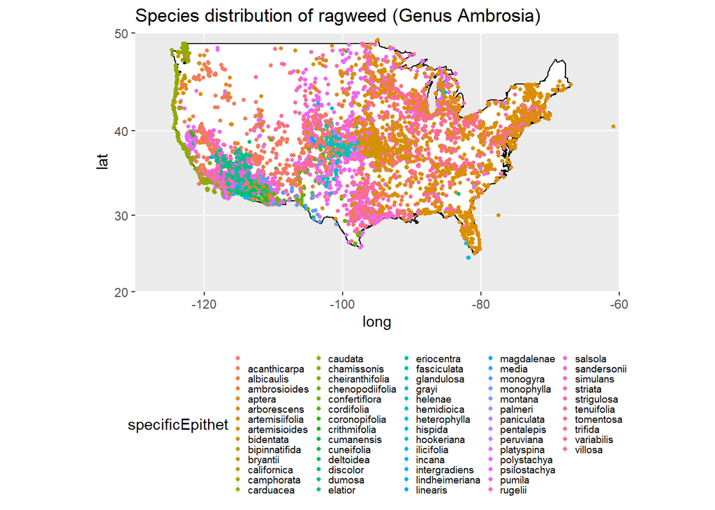

```r
# Plot with ggplot2
usa <- map_data("usa")
ggplot(usa, aes(long, lat)) +
ggtitle("Species distribution of ragweed (Genus Ambrosia)") +
geom_polygon(aes(group = group), fill = "white",
              color = "black", size = .5) +
geom_jitter(data = Ambrosia_USA, aes(decimalLongitude, decimalLatitude, color = specificEpithet), alpha=1, size = 1, show.legend = TRUE) +
coord_map(xlim = c(-130, -60), ylim = c(20, 50)) +
theme(legend.position="bottom", legend.box = "horizontal", legend.text  = element_text(size = 7), legend.key.size = unit(0.1, "lines"))
```

e.g. Spread of Zika virus, plotted by year.

```
dl_ZikaVirus <- occ_download('taxonKey = 9848767', format = "DWCA", user = user, pwd = pwd, email = email)
```

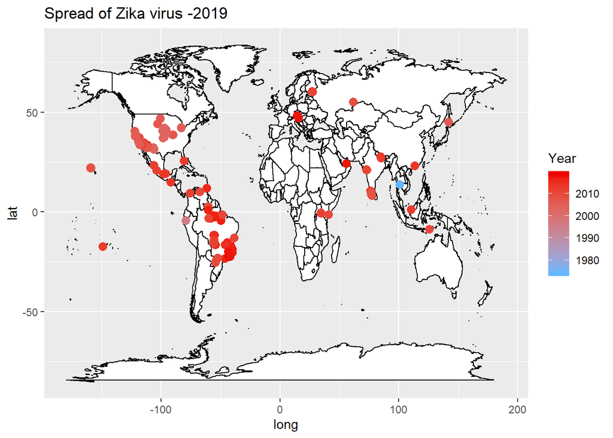

```r
# Import dowloaded data into environtment
dl_ZikaVirus <- "0007974-191105090559680"
ZikaVirus_world <- occ_download_import(key =dl_ZikaVirus)

# Plot with ggplot2
world <- map_data("world")
ggplot(world, aes(long, lat)) +
ggtitle("Spread of Zika virus -2019") +
geom_polygon(aes(group = group), fill = "white",
              color = "black", size = .5) +
geom_jitter(data = ZikaVirus_world, aes(decimalLongitude, decimalLatitude, color = year), alpha=1, size = 3, show.legend = TRUE) +
scale_color_gradient(name="Year", low="steelblue1", high="red2")
```